# index

210172276

5/16/2022

# Equality of hourly wages? Gender pay gap in EU countries

##psy6422_data_project

# Research Question

The pay gap between women and men has been widely documented and discussed especially the past few years. This begs the question: How do the EU countries stack up against each other and which ones have improved in the last few years.

# Data Origins

The gender paygap is a well documented issue, which has been heavily debated, especially in the last few years. Throughout history, women have been subjugated to receiving lower hourly wage than men. While the roles of women in today’s society have changed, we still continue to receive less pay than men doing the same job. This data is therefore looking at many countries in the EU (including UK before 2018) between 2010 and 2020. This data was reported by Eurostat. This data visualization project demonstrates the EU countries which pay men and women similar wages compared to those with a large pay gap. The data is presented as a percent of gender pay gap.

# Importing Data

```r
### reading and viewing the first original data
setwd("~/Documents/psy6422_visual_data_Assignment")
df <- read_csv(here("data","raw", "genderpaygap_raw_data.csv"))
```

```
## * `` -> ...2
## * `` -> ...3
## * `` -> ...4
## * `` -> ...5
## * `` -> ...6
## * ...
```

```r
#view first lines of original data
head(df, n = 10)
```

```
## # A tibble: 10 × 23
##    `Data extracted…` ...2  ...3  ...4  ...5  ...6  ...7  ...8  ...9  ...10 ...11
##    <chr>             <chr> <chr> <chr> <lgl> <chr> <lgl> <chr> <lgl> <chr> <lgl>
##  1 Dataset:          Gend… <NA>  <NA>  NA    <NA>  NA    <NA>  NA    <NA>  NA
##  2 Last updated:     25/0… <NA>  <NA>  NA    <NA>  NA    <NA>  NA    <NA>  NA
##  3 <NA>              <NA>  <NA>  <NA>  NA    <NA>  NA    <NA>  NA    <NA>  NA
##  4 Time frequency    <NA>  Annu… <NA>  NA    <NA>  NA    <NA>  NA    <NA>  NA
##  5 Unit of measure   <NA>  Perc… <NA>  NA    <NA>  NA    <NA>  NA    <NA>  NA
##  6 Statistical clas… <NA>  Indu… <NA>  NA    <NA>  NA    <NA>  NA    <NA>  NA
##  7 <NA>              <NA>  <NA>  <NA>  NA    <NA>  NA    <NA>  NA    <NA>  NA
##  8 TIME              2010  <NA>  2011  NA    2012  NA    2013  NA    2014  NA
##  9 GEO (Labels)      <NA>  <NA>  <NA>  NA    <NA>  NA    <NA>  NA    <NA>  NA
## 10 European Union -… 15.8  <NA>  16.2  NA    16.4  NA    16.0  NA    15.7  NA
## # … with 12 more variables: ...12 <chr>, ...13 <chr>, ...14 <chr>, ...15 <chr>,
## #   ...16 <chr>, ...17 <chr>, ...18 <chr>, ...19 <chr>, ...20 <chr>,
## #   ...21 <chr>, ...22 <chr>, ...23 <chr>
```

# Data Preperation

```r
#organize data to remove NA and unnecessary rows
df1 <- df[1,1]
df1 <- df[2,1]
df1 <- df[,-1]
df1 <- df[]
df1 <- c(1:10)
df1 <- df[-c(1:9),]
df1 <- seq(3,21,2)
df1 <- df[-c(33:46),]

df1 <- df[-c(1:9,42:55 ),-seq(3,23,2)]
```

```r
#renaming the columns of the original data set
colnames(df1) <- c("country", "2010" , "2011" , "2012" , "2013" , "2014" , "2015" , "2016" , "2017" , "2018" , "2019" , "2020")
```

```r
#changign the data from each year to numeric from character
df1$`2010` <- as.numeric(df1$`2010`)
df1$`2011` <- as.numeric(df1$`2011`)
df1$`2012` <- as.numeric(df1$`2012`)
df1$`2013` <- as.numeric(df1$`2013`)
df1$`2014` <- as.numeric(df1$`2014`)
df1$`2015` <- as.numeric(df1$`2015`)
df1$`2016` <- as.numeric(df1$`2016`)
df1$`2017` <- as.numeric(df1$`2017`)
df1$`2018` <- as.numeric(df1$`2018`)
df1$`2019` <- as.numeric(df1$`2019`)
df1$`2020` <- as.numeric(df1$`2020`)
```

```r
#changing column names to fit with rbind
colnames(df1) <- c("country", "data" , "2011" , "2012" , "2013" , "2014" , "2015" , "2016" , "2017" , "data" , "2019" , "2020")
df2 <- rbind(df1[ ,c(1,2)] , df1[ , c(1,10)])
df2$year <- 2010
df2$year[c(33:64)] <- 2018
#changing year into character from numeric
df2$year <- as.character(df2$year)
head(df2)
```

```
## # A tibble: 6 × 3
##   country                                           data year
##   <chr>                                            <dbl> <chr>
## 1 European Union - 27 countries (from 2020)         15.8 2010
## 2 Belgium                                           10.2 2010
## 3 Bulgaria                                          13   2010
## 4 Czechia                                           21.6 2010
## 5 Denmark                                           17.1 2010
## 6 Germany (until 1990 former territory of the FRG)  22.3 2010
```

# Visualization 1: EU countries pay gap 2010 vs 2018

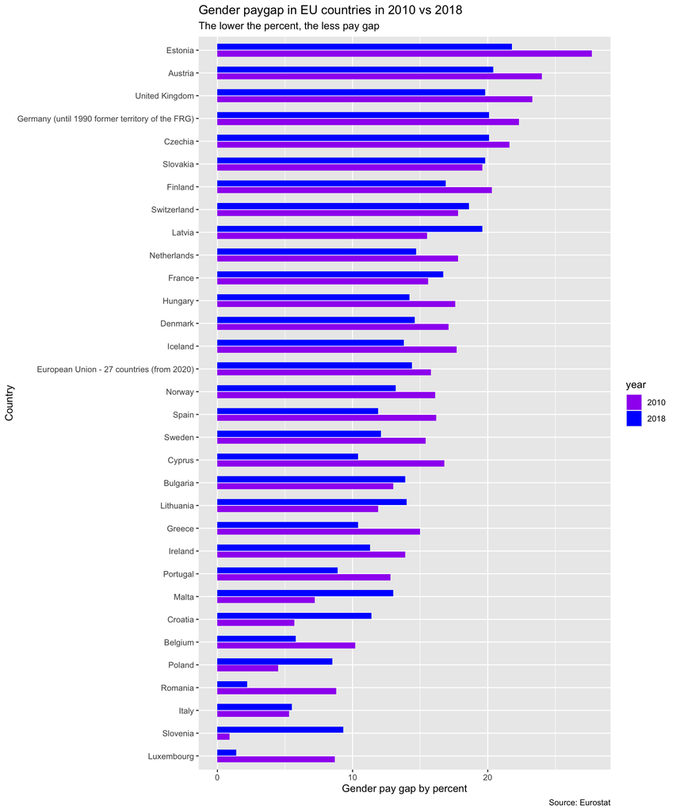

```r
#Bar chart representing the gender pay gap between the earliest year, 2010 and the latest date including UK data, 2018.
ggplot(data = df2, aes(x = reorder(country , `data`) , y = `data` , fill = year)) + coord_flip() + geom_col(width = 0.6 , position = position_dodge2(preserve = "single" , width = 0.8)) +scale_fill_manual(values= c("purple" , "blue"))+ labs(title = "Gender paygap in EU countries in 2010 vs 2018" , subtitle =  "The lower the percent, the less pay gap", caption = "Source: Eurostat" , x = "Country", y = "Gender pay gap by percent")
```